# The Data Incubator

January 2019 Cohort

## Capstone Project

Veronica Lee  
March, 2019

## I. Definition

### 1. Project Overview:

1. Objective:
   - Predict the M&A event occurrence of the US public company based on the company information and CEO's biographic and psychological attributes.
     - For CEO's psychological attributes, I will identify the risk-taking nature of CEO of the NYSE Public companies, using **[Regulatory Focus theory](https://en.wikipedia.org/wiki/Regulatory_focus_theory)**.
     - Examine if CEO's regulatory focus impacts on his/her decision making on the company event such as company acquisitions. (i.e., "M&A")
2. Audience:
   - 1.1. Institutional Investor who would like to get supplementary analysis on the future M&A possibilities of their invested companies/equities
   - 1.2. Individual Stockholders of the company who wants to forecast company action/event that may impact on the company value and earning shocks.

### 2. Problem Statement

- *Research Question*: Does CEO's regulatory focus(i.e, psychological character towards risky behavior) impact on his/her decision on company action with high risk, such as mergers and acquisitions (M&A)?
- *Hypothesis*: CEO with promotion regulatory focus (i.e., rist-taking psychological attribute) is more likely to decide M&A, comparing to CEO with prevention regulatory focus.

Based on CEO's verbiage choices used in their letters to shareholders in the company annual reports, I will classify CEO's psychological attributes in to two regulatory focus classes: (1) promotion focus and (2) prevention focus. Once I classify CEO regulatory focus and create regulatory foci variables, I will find the relationship between CEO's regulatory focus and occurence of M&A, along with other variables, such as CEO compensation/biographic information and company infromation that may potentially impact on CEO's M&A decision.

### 3. Metrics

- Company information:
  - `ln_firmsize`: Natural log-transformed company size (Total Revenue, collected from WRDS)
  - Previous M&A records:
    - `acq_ct`: total counts of previous acquisitions a company had made between 1996 and 2016
    - `acq_val`: log-transformed total acquisition values (i.e., deal values in USD millions) a company had spent in M&A between 1996 and 2016
    - `acq`: M&A occurence binary variable (1, if a company had previously acquired other companies, 0, if a company never had acquisition.)
  - Sector information of the company: My final data had total 13 sectors: 'Finance', 'Capital Goods', 'Transportation', 'Consumer Services', 'Unknown', 'Health Care', 'Technology', 'Public Utilities', 'Energy', 'Miscellaneous', 'Consumer Non-Durables', 'Basic Industries', 'Consumer Durables'
- CEO Biographic information:
  - `age`: CEO's age
  - `net_income`: CEO's net income
  - `bonus`: CEO's compensation bonus
  - `restricted stocks`: CEO's restricted stocks
- CEO Psychological Attributes:
  - Regulatory Focus:
    - `prom_pct`: total counts of promotional words term-frequency(TF score) appeared in the CEO's shareholder letter, comparing to the promotion regulatory focus dictionary, which includes total 25 promotional regulatory. I double-counted the same vocabulary to calculate the percentage. For example, if "motivation" was the promotional regulatory focus word listed as a key in the regulatory focus dictionary and CEO used this word twice in his/her letter, I added two, instead of one to count the promotional regulatory focus vocabs term frequency.
    - `prev_pct`: total counts of promotional words term-frequency(TF score) appeared in the CEO's shareholder letter, comparing to the promotion regulatory focus dictionary, which includes total 25 promotional regulatory.
    - `regfoci`: If CEO's `prom_pct` is higher than `prev_pct`, I gave a dummy variable 1, and classified this CEO as the CEO with promotional regulatory focus and vice versa.
    - `regfoci_score`: `prom_pct` - `prev_pct`

## II. Analysis

### Data Exploration

#### CEO shareholder's letter data

I collected total 7367 CEO shareholder's letters from 10-K annual reports listed at http://annualreports.com for 973 publicly traded companies in the U.S. between 1996 and 2016. Using NLTK, I created corpus for each company by year and counted the term-frequency(TF) used for the promotion focus words and prevention focus words used by the CEOs in their letters. Using this TF matrix for promotion focus words and prevention focus words respectively, I calculated the the percentage of promotion/prevention focus words against total promtion/prevention focus words in the dictionary used by the CEO per letter.

#### CEO compensation data

I collected CEO compensation data including CEO net income, bonus, restricted stocks and salary from Wharton's WRDS database.

#### Previous Company M&A records

I collected historical M&A records for 973 publicly traded companied in the U.S. between 1996 and 2016 from SDC M&A database and caclulted log transformed M&A deal values in $USD millions spent by each company, total count of past acquisitions by company. Based on the M&A information given in this data set, I created a binary dummy variable tells the past M&A occurence of the company. If the company had ever acquired another company, I gave "1", otherwise, "0".

#### Other Company Information

I collected company sector information for 973 publicly traded companied in the U.S. between 1996 and 2016 from SDC M&A database and firm size (i.e., total revenue of the company) from the WRDS CEO biographic information Acceess Relational Database, using SQL.

### Exploratory Data Visualization

Counts of companies by previous acquistion counts

[figure not shown]

Counts of companies by CEO regulatory focus

[figure not shown]

Counts of company by CEO promotion focus %

[figure not shown]

Counts of company by CEO prevention focus %

[figure not shown]

Counts of company for sector

[figure not shown]

Correlation Plot

[figure not shown]

## III. Model Implementation/Evaluation

### Data Pre-processing

```python
###################  Load Required Packages ###################
import os

# Import modules for data visualization/plotting
import matplotlib
import seaborn as sns
sns.set()
matplotlib.rcParams['figure.dpi'] = 144
import matplotlib.pyplot as plt
from bokeh.plotting import figure, show
from bokeh.io import output_notebook

# Import Pands/Numpy/statsmodel/scikit-learn
import pandas as pd
import numpy as np
import statsmodels.api as sm
import sklearn

# Import Sampling Helper
from sklearn.model_selection import train_test_split

# Import preprocessing modulesPython
from sklearn import preprocessing
import spacy

# Import scikit-learn ML Models
from sklearn.ensemble import RandomForestRegressor

# Import cross-validation pipeline
from sklearn.pipeline import make_pipeline
from sklearn.model_selection import GridSearchCV

# Import Evaluation metrics
from sklearn.metrics import mean_squared_error, r2_score

# Import module for saving scikit-learn ML models
import dill
from sklearn.externals import joblib
```

```python
dpath = "/home/jovyan/Capstone-VL/data" # data files saved path
opath = "/home/jovyan/Capstone-VL/code" # original path

# Check current working directory.
retval = os.getcwd()
print("Current working directory %s" % retval)

# Now change the directory
os.chdir(dpath)

# Change if you would like to pull data from different file path: "dpath"
# os.chdir(opath)

# Check current working directory.
retval = os.getcwd()
print("Directory changed successfully %s" % retval)
```

```
Current working directory /home/jovyan/Capstone-VL/code
Directory changed successfully /home/jovyan/Capstone-VL/data
```

### Cleaned data load

Loading the interim data which joined (1) CEO promotion/prevention regulatory foci data (2) Company information (3) M&A data (counts and values) and (4) CEO biographic information.

All of the collected data is saved under the `data` folder.

```python
###################  Load Data ###################

# Load interim data merged (1) CEO compensation data (2) CEO Reg foci percentage (3) Company data for data analysis
dta = pd.read_csv("./data_0211.csv")
prom_df = pd.read_csv("./promotion_frequency.csv")
prev_df = pd.read_csv("./prevention_frequency.csv")
```

```python
data = pd.read_csv("./data_preprocessed.csv")
data = data.drop([data.columns[0]], axis=1)
data = data.drop(columns='sector_cat')
data.head()
```

|  | file_name | market | ticker | name | sector | year | identifier | prev_pct | prom_pct | acq_ct | ... | Consumer Services | Energy | Finance | Health Care | Miscellaneous | Public Utilities | Technology | Transportation | Unknown | sect_cat |
| --- | --- | --- | --- | --- | --- | --- | --- | --- | --- | --- | --- | --- | --- | --- | --- | --- | --- | --- | --- | --- | --- |
| 0 | NASDAQ_AAME_1999 | NASDAQ | AAME | Atlantic American Corporation | Finance | 1999 | AAME1999 | 0.04 | 0.074074 | 2 | ... | 0 | 0 | 1 | 0 | 0 | 0 | 0 | 0 | 0 | 7 |
| 1 | NASDAQ_AAME_2000 | NASDAQ | AAME | Atlantic American Corporation | Finance | 2000 | AAME2000 | 0.08 | 0.481481 | 0 | ... | 0 | 0 | 1 | 0 | 0 | 0 | 0 | 0 | 0 | 7 |
| 2 | NASDAQ_AAME_2001 | NASDAQ | AAME | Atlantic American Corporation | Finance | 2001 | AAME2001 | 0.32 | 0.259259 | 0 | ... | 0 | 0 | 1 | 0 | 0 | 0 | 0 | 0 | 0 | 7 |
| 3 | NASDAQ_AAME_2002 | NASDAQ | AAME | Atlantic American Corporation | Finance | 2002 | AAME2002 | 0.16 | 0.296296 | 0 | ... | 0 | 0 | 1 | 0 | 0 | 0 | 0 | 0 | 0 | 7 |
| 4 | NASDAQ_AAME_2004 | NASDAQ | AAME | Atlantic American Corporation | Finance | 2004 | AAME2004 | 0.52 | 0.148148 | 0 | ... | 0 | 0 | 1 | 0 | 0 | 0 | 0 | 0 | 0 | 7 |

5 rows × 35 columns

```python
print("cleaned data shape:",dta.shape)
print("super clean data shape:", data.shape)
print("CEO promotion focus DF shape: ",prom_df.shape)
print("CEO prevention focus DF shape: ",prev_df.shape)

# we are going to use dta dataframe for the major data analysis.
```

```
cleaned data shape: (7367, 20)
super clean data shape: (7367, 35)
CEO promotion focus DF shape:  (7367, 34)
CEO prevention focus DF shape:  (7367, 33)
```

```python
data.dtypes
```

```
file_name                 object
market                    object
ticker                    object
name                      object
sector                    object
year                       int64
identifier                object
prev_pct                 float64
prom_pct                 float64
acq_ct                     int64
acq_val                  float64
firmsize_str              object
firmsize                 float64
ceo_age                  float64
net_income               float64
salary                   float64
bonus                    float64
restricted_stocks        float64
acq                        int64
regfoci                    int64
regfoci_score            float64
ln_firmsize              float64
Capital Goods              int64
Consumer Durables          int64
Consumer Non-Durables      int64
Consumer Services          int64
Energy                     int64
Finance                    int64
Health Care                int64
Miscellaneous              int64
Public Utilities           int64
Technology                 int64
Transportation             int64
Unknown                    int64
sect_cat                   int64
dtype: object
```

### Imbalanced Acquisition Data Treatment

#### Resampling

Deal with the imbalanced labels so you might want to reexamine that first and foremost

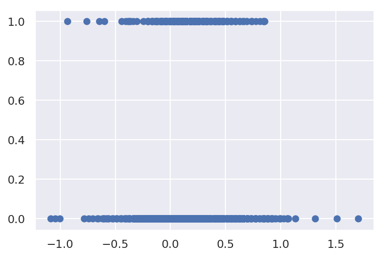

```python
import numpy as np
import matplotlib.pyplot as plt
from sklearn.linear_model import LinearRegression

np.random.seed(123)
plt.scatter(data.regfoci_score, data.acq)
plt.show()
```

### Imbalance class treatment for the target variable

A target variable `acq` is imbalanced, as around 8% M&A occurrence is balanced to no M&A occurrence. I'll up-sample minority class in `acq`.

```python
# Count the total data points for each historical M&A occurrence in binary classification
# 0: No M&A occurred, 1: M&A occurred.
data['acq'].value_counts()
# 0    6773
# 1     594
# Name: acq, dtype: int64
```

```
0    6773
1     594
Name: acq, dtype: int64
```

```python
594/(6773+594) # about 8.06 % were balanced.
```

```
0.08062983575403827
```

```python
# Module for resampling
from sklearn.utils import resample

# Upsample minority class
# Separate majority and minority classes
target_majority = data[data.acq==0]
target_minority = data[data.acq==1]

# Upsample minority class
target_minority_upsampled = resample(target_minority,
                                 replace=True,     # sample with replacement
                                 n_samples=6773,   # to match majority class
                                 random_state=123) # reproducible results

# Combine majority class with upsampled minority class
data_upsampled = pd.concat([target_majority, target_minority_upsampled])

# Display new class counts
data_upsampled.acq.value_counts()
# 1    6773
# 0    6773
# Name: acq, dtype: int64
```

```
1    6773
0    6773
Name: acq, dtype: int64
```

#### Train model on upsampled dataset

```python
print(len(data_upsampled[data_upsampled['acq']==1]))
data_upsampled[data_upsampled['acq']==1].head()
```

```
6773
```

|  | file_name | market | ticker | name | sector | year | identifier | prev_pct | prom_pct | acq_ct | ... | Consumer Services | Energy | Finance | Health Care | Miscellaneous | Public Utilities | Technology | Transportation | Unknown | sect_cat |
| --- | --- | --- | --- | --- | --- | --- | --- | --- | --- | --- | --- | --- | --- | --- | --- | --- | --- | --- | --- | --- | --- |
| 6159 | NASDAQ_SFNC_2013 | NASDAQ | SFNC | Simmons First National Corporation | Finance | 2013 | SFNC2013 | 0.04 | 0.074074 | 2 | ... | 0 | 0 | 1 | 0 | 0 | 0 | 0 | 0 | 0 | 7 |
| 4575 | NASDAQ_MANT_2012 | NASDAQ | MANT | ManTech International Corporation | Consumer Services | 2012 | MANT2012 | 0.20 | 0.111111 | 2 | ... | 1 | 0 | 0 | 0 | 0 | 0 | 0 | 0 | 0 | 5 |
| 4711 | NASDAQ_MHGC_2011 | NASDAQ | MHGC | Unknown | Unknown | 2011 | MHGC2011 | 0.00 | 0.481481 | 2 | ... | 0 | 0 | 0 | 0 | 0 | 0 | 0 | 0 | 1 | 13 |
| 3937 | NASDAQ_IMMR_2000 | NASDAQ | IMMR | Immersion Corporation | Technology | 2000 | IMMR2000 | 0.00 | 0.111111 | 2 | ... | 0 | 0 | 0 | 0 | 0 | 0 | 1 | 0 | 0 | 11 |
| 1177 | NASDAQ_BRCM_2010 | NASDAQ | BRCM | Unknown | Unknown | 2010 | BRCM2010 | 0.00 | 0.148148 | 4 | ... | 0 | 0 | 0 | 0 | 0 | 0 | 0 | 0 | 1 | 13 |

5 rows × 35 columns

```python
data_upsampled.columns
```

```
Index(['file_name', 'market', 'ticker', 'name', 'sector', 'year', 'identifier',
       'prev_pct', 'prom_pct', 'acq_ct', 'acq_val', 'firmsize_str', 'firmsize',
       'ceo_age', 'net_income', 'salary', 'bonus', 'restricted_stocks', 'acq',
       'regfoci', 'regfoci_score', 'ln_firmsize', 'Capital Goods',
       'Consumer Durables', 'Consumer Non-Durables', 'Consumer Services',
       'Energy', 'Finance', 'Health Care', 'Miscellaneous', 'Public Utilities',
       'Technology', 'Transportation', 'Unknown', 'sect_cat'],
      dtype='object')
```

### Logistic Regression

```python
# Import model algorithm and accuracy metric
from sklearn.linear_model import LogisticRegression
from sklearn.metrics import accuracy_score

# Separate input features (X) and target variable (y)

select_vars = [ # CEO compensation information
               'ceo_age', 'net_income', 'salary', 'bonus', 'restricted_stocks',
                # CEO regulatory focus score
               'regfoci_score',
                # log-transformed company size
               'ln_firmsize',
                # Company sectors (13-1 sector to avoid multicollinearity)
               'Capital Goods', 'Technology', 'Transportation', 'Unknown',
               'Consumer Durables', 'Consumer Non-Durables', 'Consumer Services',
               'Energy', 'Finance', 'Health Care', 'Miscellaneous', 'Public Utilities']

# Split Train/Test data set: Using Upsampled feature data set X & Upsampled target data set y.
y = data_upsampled.acq
X = data_upsampled[select_vars]
X_train, X_test, y_train, y_test = train_test_split(X, y, test_size=0.3, random_state=seed)

# Train model
clf_1 = LogisticRegression().fit(X, y)
clf_1_train = LogisticRegression().fit(X_train, y_train)


# Predict on training set
pred_y_1 = clf_1.predict(X)
pred_y_1_train = clf_1.predict(X_train)

# Is a model predicting just one class?
print( np.unique( pred_y_1 ) )
# [0 1]
print( np.unique( pred_y_1_train ) )
# [0 1]

# How's accuracy?
print( accuracy_score(y, pred_y_1) )
# 0.6438062896796102
print( accuracy_score(y_train, pred_y_1_train) )
# 0.6424804893482388
```

```
[0 1]
[0 1]
0.6438062896796102
0.6424804893482388
```

### Model Validation/Evaluation: Logistic Regression

#### Area Under ROC Curve

```python
from sklearn.metrics import roc_auc_score

# Predict class probabilities
prob_y_1 = clf_1.predict_proba(X)

# Keep only the positive class
prob_y_1 = [p[1] for p in prob_y_1]

prob_y_1[:5] # Example
# [0.19857015426192284,
#  0.2121262199679234,
#  0.20626631881423585,
#  0.22162447280566636,
#  0.20535210611253116]
```

```
[0.19857015426192284,
 0.2121262199679234,
 0.20626631881423585,
 0.22162447280566636,
 0.20535210611253116]
```

```python
# AUROC of model trained on upampled dataset
print( roc_auc_score(y, prob_y_1) )
# 0.6943948001035629
```

```
0.6943948001035629
```

```python
# AUROC of model trained on imbalanced dataset

y_imbalanced = data['acq']
X_imbalanced = data[select_vars]

prob_y_0 = clf_1.predict_proba(X_imbalanced)
prob_y_0 = [p[1] for p in prob_y_0]

print( roc_auc_score(y_imbalanced, prob_y_0) )
# 0.6887408461304815
```

```
0.6887408461304815
```

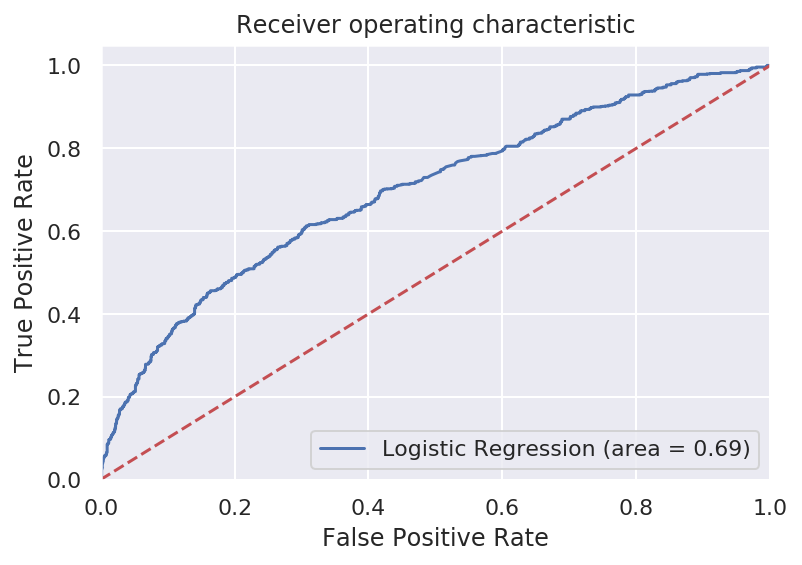

```python
# ROC curve

from sklearn.metrics import roc_auc_score
from sklearn.metrics import roc_curve



logit_roc_auc = roc_auc_score(y, prob_y_1)
fpr, tpr, thresholds = roc_curve(y_test, clf_1.predict_proba(X_test)[:,1])
plt.figure()
plt.plot(fpr, tpr, label='Logistic Regression (area = %0.2f)' % logit_roc_auc)
plt.plot([0, 1], [0, 1],'r--')
plt.xlim([0.0, 1.0])
plt.ylim([0.0, 1.05])
plt.xlabel('False Positive Rate')
plt.ylabel('True Positive Rate')
plt.title('Receiver operating characteristic')
plt.legend(loc="lower right")
plt.savefig('Log_ROC_updated.png')
plt.show()
```

#### Confusion Matrix

My logistic regression's average precision/recall is 0.65, respectively. F1 score's average is 0.64 for predicting M&A occurrence.

1. Precision = TP/(TP + FP) – Accuracy of positive predictions.
2. Recall = TP/(TP+FN) – The ability of a classifier to find all positive instances.

```python
1450/(1460+610) # Precision: 0.7004830917874396
1450/(1450+828) # Recall: 0.636523266022827
```

[output not shown]

```
[[1450  610]
 [ 828 1176]]
             precision    recall  f1-score   support

          0       0.64      0.70      0.67      2060
          1       0.66      0.59      0.62      2004

avg / total       0.65      0.65      0.64      4064
```

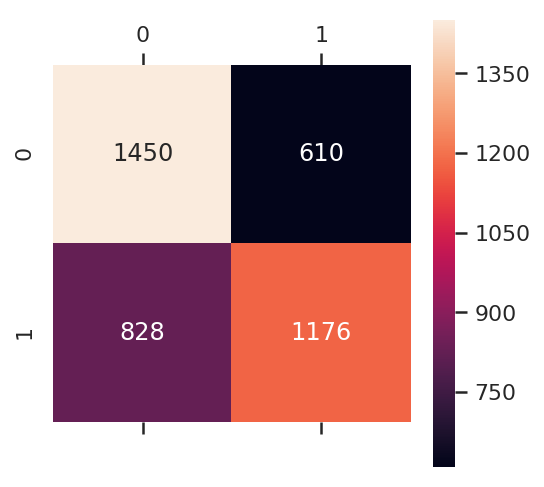

```python
model1 = LogisticRegression()
model1 = model1.fit(X_train, y_train)
model1_pred = model1.predict(X_test)
cm=metrics.confusion_matrix(y_test,model1_pred)
print(cm)
plt.matshow(cm, cmap='binary')
sns.heatmap(cm, annot=True, fmt='d')
plt.savefig('confusionmat_logit.png')

print(metrics.classification_report(y_test,model1_pred))
# [[1450  610] TP FP
#  [ 828 1176]]FN TN
```

### Polynomial Features Regression Model

Should I allow for interactions between my categorical variables? (company sector information)

```python
from sklearn.preprocessing import PolynomialFeatures

def create_polynomial_regression_model(degree):
    "Creates a polynomial regression model for the given degree"
    poly_features = PolynomialFeatures(interaction_only= True, include_bias = False, degree=degree)

    # transforms the existing features to higher degree features.
    X_train_poly = poly_features.fit_transform(X_train)

    # fit the transformed features to Linear Regression
    poly_model = LinearRegression()
    poly_model.fit(X_train_poly, y_train)

    # predicting on training data-set
    y_train_predicted = poly_model.predict(X_train_poly)

    # predicting on test data-set
    y_test_predict = poly_model.predict(poly_features.fit_transform(X_test))

    # evaluating the model on training dataset
    rmse_train = np.sqrt(mean_squared_error(y_train, y_train_predicted))
    r2_train = r2_score(y_train, y_train_predicted)

    # evaluating the model on test dataset
    rmse_test = np.sqrt(mean_squared_error(y_test, y_test_predict))
    r2_test = r2_score(y_test, y_test_predict)

    print("The model performance for the training set")
    print("-------------------------------------------")
    print("RMSE of training set is {}".format(rmse_train))
    print("R2 score of training set is {}".format(r2_train))

    print("\n")

    print("The model performance for the test set")
    print("-------------------------------------------")
    print("RMSE of test set is {}".format(rmse_test))
    print("R2 score of test set is {}".format(r2_test))
```

```python
create_polynomial_regression_model(1)
```

```
The model performance for the training set
-------------------------------------------
RMSE of training set is 0.4687315967691803
R2 score of training set is 0.12113210587159606


The model performance for the test set
-------------------------------------------
RMSE of test set is 0.4686208796071627
R2 score of test set is 0.12141106237666033
```

```python
create_polynomial_regression_model(2)
```

```
The model performance for the training set
-------------------------------------------
RMSE of training set is 0.4476888800002102
R2 score of training set is 0.19827070259961277


The model performance for the test set
-------------------------------------------
RMSE of test set is 0.44994732309612057
R2 score of test set is 0.19003583350084252
```

```python
create_polynomial_regression_model(3)
```

```
The model performance for the training set
-------------------------------------------
RMSE of training set is 0.41766362682571767
R2 score of training set is 0.302204040202243


The model performance for the test set
-------------------------------------------
RMSE of test set is 0.5038664856549174
R2 score of test set is -0.015718601420112943
```

```python
from patsy import dmatrices

# I will come back and run this after final feature selection (iff I have relatively small number of features.)

# create dummy variables, and their interactions
X_interaction, y_interaction = dmatrices('acq ~ C(regfoci_score)*C(net_income)', data, return_type="dataframe")
# flatten y into a 1-D array so scikit-learn can understand it
y_interaction_flatten = np.ravel(y_interaction)
```

Interaction terms among sector variables will not be considered at the moment in this project.

### Model Selection: Algorithm comparison using cross validation score function

```
LR: -0.220754 (0.004767)
LASSO: -0.243542 (0.002604)
EN: -0.243533 (0.002607)
KNN: -0.106734 (0.006987)
CART: -0.063360 (0.006040)
SVR: -0.141276 (0.005758)
LOGR: -0.358362 (0.014181)
```

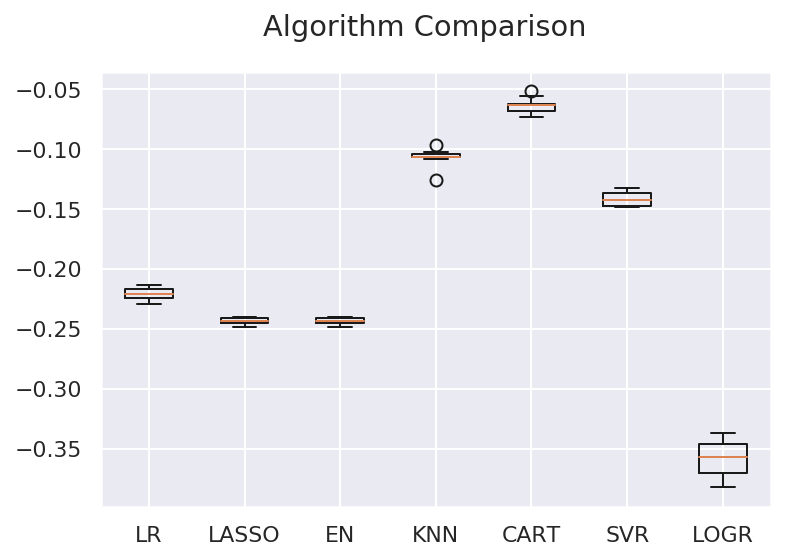

```python
import matplotlib.pyplot as plt

from sklearn.cross_validation import train_test_split
from sklearn.model_selection import *

from sklearn.linear_model import *
from sklearn.neighbors import *
from sklearn.tree import *
from sklearn.svm import *


# Test Options and Evaluation Metrics
num_folds = 10
scoring = "neg_mean_squared_error"
# loss function as a scoring par
# neg_mean_squared_error_scorer = make_scorer(mean_squared_error,greater_is_better=False)
seed = 123

# Split Train/Test data set: Using Upsampled feature data set X & Upsampled target data set y.
y = data_upsampled.acq
X = data_upsampled[select_vars]
X_train, X_test, y_train, y_test = train_test_split(X, y, test_size=0.3, random_state=seed)

# Spot Check Algorithms
models = []
models.append(('LR', LinearRegression()))
models.append(('LASSO', Lasso()))
models.append(('EN', ElasticNet()))
models.append(('KNN', KNeighborsRegressor()))
models.append(('CART', DecisionTreeRegressor()))
models.append(('SVR', SVR())) # Epsilon-Support Vector Regression.
models.append(('LOGR', LogisticRegression()))


results = []
names = []
for name, model in models:
    kfold = KFold(n_splits=num_folds, random_state=seed)
    cv_results = cross_val_score(model, X_train, y_train, cv=kfold, scoring=scoring)
    results.append(cv_results)
    names.append(name)
    msg = "%s: %f (%f)" % (name, cv_results.mean(),   cv_results.std())
    print(msg)


# LR: -0.220754 (0.004767)
# LASSO: -0.243542 (0.002604)
# EN: -0.243533 (0.002607)
# KNN: -0.106734 (0.006987)
# CART: -0.063360 (0.006040)
# SVR: -0.141276 (0.005758)
# LOGR: -0.358362 (0.014181)

# Compare Algorithms
fig = plt.figure()
fig.suptitle('Algorithm Comparison')
ax = fig.add_subplot(111)
plt.boxplot(results)
ax.set_xticklabels(names)
plt.show()
plt.savefig('algo_comparison.png')
```

I compared 7 different model algorithms (Linear Regression, Lasso, EN, KNN, CART, SVR, Logistic Regression) to select the best algorithm for M&A occurrence prediction. Per cross-validation score driven algorithm comparsion, CART yielded the best cross validation mean score, followed by KNN. Logistic Regression had the largest cross validation measn score, scored with MSE.

### Dimensionality Reduction: PCA

```python
features = select_vars
len(features) # we have 19 variables for the initially selected features set = 19 dimensions
```

```
19
```

#### Feature Scaling : Standardization

```python
from sklearn.preprocessing import StandardScaler
from sklearn.model_selection import GridSearchCV

# Build a scaler using "standardization":
# (X−μ)/σ  WHERE σ is Standard Deviation and μ is mean.
scaler = StandardScaler().fit(X_train)
rescaledX = scaler.transform(X_train)
rescaledX_test = scaler.transform(X_test)
rescaled_X_all = StandardScaler().fit_transform(X)
```

```python
len(rescaled_X_all)
```

```
13546
```

```python
from sklearn.decomposition import PCA

pca = PCA(n_components=2)
principalComponents = pca.fit_transform(rescaled_X_all)
principalDf = pd.DataFrame(data = principalComponents
             , columns = ['principal component 1', 'principal components2'])
```

```python
finalpcadf = pd.merge(principalDf,data_upsampled[['acq']], left_index=True,right_index=True)
```

```python
finalpcadf.isnull().sum()
```

```
principal component 1    0
principal components2    0
acq                      0
dtype: int64
```

#### Visualize 2D Projection after PCA

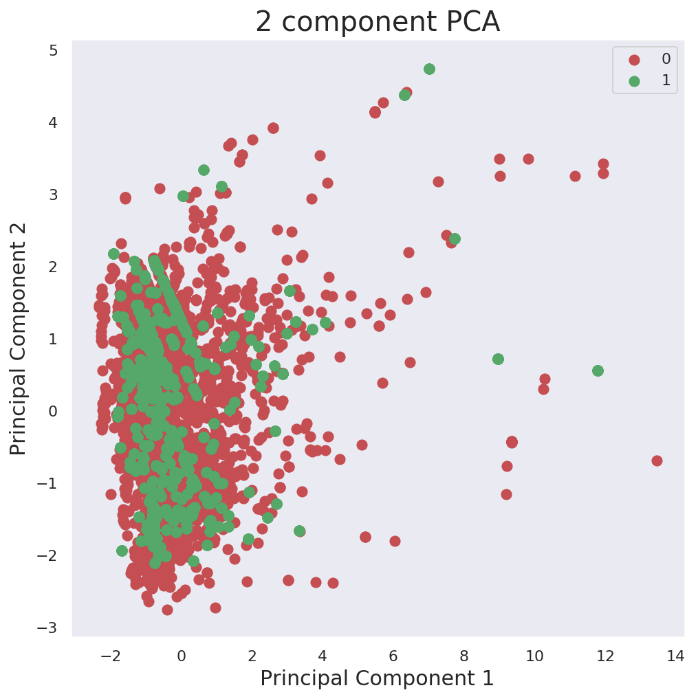

```python
fig = plt.figure(figsize = (8,8))
ax = fig.add_subplot(1,1,1)
ax.set_xlabel('Principal Component 1', fontsize = 15)
ax.set_ylabel('Principal Component 2', fontsize = 15)
ax.set_title('2 component PCA', fontsize = 20)
targets = [0,1]
colors = ['r', 'g']
for target, color in zip(targets,colors):
    indicesToKeep = finalpcadf['acq'] == target
    ax.scatter(finalpcadf.loc[indicesToKeep, 'principal component 1']
               , finalpcadf.loc[indicesToKeep, 'principal components2']
               , c = color
               , s = 50)
ax.legend(targets)
ax.grid()

from matplotlib import pyplot as plt
plt.savefig('2comppca.png')
```

```python
pca.explained_variance_ratio_
# first principal component contains 12.52% of the variance
# second principal component contains 7.51% of the variance.
# Together, the two components contain around 20% of the information.
```

```
array([0.12515679, 0.07513381])
```

```python
0.12515679 + 0.07513381
```

```
0.20029059999999999
```

According to the 2 component PCA analysis above, first principal component contains 12.52% of the variance; second principal component contains 7.51% of the variance. Together, the two components contain around 20% of the information.

### Tunning The Model’s Hyperparameters

Here, I tuned hyperparameters for CART model, which is selected as the best algorithm for prediction earlier. With GridSearchCV, I will find the best maximum depth of the tree and tune hypterparameter in CART model with it.

```python
# Build parameter grid
c_values = [0.1, 0.3, 0.5, 0.7, 0.9, 1.0, 1.3, 1.5, 1.7, 2.0]
kernel_values = ['linear', 'poly', 'rbf', 'sigmoid']
param_grid = dict(max_depth=np.arange(3,10))

# Choose this param_grid if the model is SVC()
# param_grid = dict(C=c_values, kernel=kernel_values)

# Build the model
# model = SVC()
model = DecisionTreeRegressor()
kfold = KFold(n_splits=num_folds, random_state=seed)
grid = GridSearchCV(estimator=model, param_grid=param_grid, scoring=scoring, cv=kfold)
grid_result = grid.fit(rescaledX, y_train)

# Show the results
print("Best: %f using %s" % (grid_result.best_score_, grid_result.best_params_))
means = grid_result.cv_results_['mean_test_score']
stds = grid_result.cv_results_['std_test_score']
params = grid_result.cv_results_['params']
for mean, stdev, param in zip(means, stds, params):
    print("%f (%f) with: %r" % (mean, stdev, param))

#     Best: -0.174224 using {'max_depth': 9}
# -0.221344 (0.005321) with: {'max_depth': 3}
# -0.216349 (0.005150) with: {'max_depth': 4}
# -0.211243 (0.006125) with: {'max_depth': 5}
# -0.204141 (0.005560) with: {'max_depth': 6}
# -0.193967 (0.006002) with: {'max_depth': 7}
# -0.184609 (0.006931) with: {'max_depth': 8}
# -0.174224 (0.005558) with: {'max_depth': 9}
```

```
Best: -0.174224 using {'max_depth': 9}
-0.221344 (0.005321) with: {'max_depth': 3}
-0.216349 (0.005150) with: {'max_depth': 4}
-0.211243 (0.006125) with: {'max_depth': 5}
-0.204141 (0.005560) with: {'max_depth': 6}
-0.193967 (0.006002) with: {'max_depth': 7}
-0.184609 (0.006931) with: {'max_depth': 8}
-0.174224 (0.005558) with: {'max_depth': 9}
```

Default parameters for CART in sklearn:

- DecisionTreeRegressor(criterion=’mse’, splitter=’best’, max_depth=None, min_samples_split=2, min_samples_leaf=1, min_weight_fraction_leaf=0.0, max_features=None, random_state=None, max_leaf_nodes=None, min_impurity_decrease=0.0, min_impurity_split=None, presort=False)[source]

### CART Model: Make a prediction with best model with tuned hypter parameter

AUROC score is about 74% - thus, over-fitting issue is not a severe concern with this model.

Precision = TP/(TP + FP) – Accuracy of positive predictions. Recall = TP/(TP+FN) – The ability of a classifier to find all positive instances.

```python
# Decision Tree Classifier
from sklearn import metrics
from sklearn.metrics import roc_auc_score
from sklearn.tree import DecisionTreeClassifier

# fit a CART model to the data
tree = DecisionTreeRegressor(random_state = seed, max_depth=9)
tree_fit = tree.fit(rescaledX, y_train)
print(tree)
```

```
DecisionTreeRegressor(criterion='mse', max_depth=9, max_features=None,
           max_leaf_nodes=None, min_impurity_decrease=0.0,
           min_impurity_split=None, min_samples_leaf=1,
           min_samples_split=2, min_weight_fraction_leaf=0.0,
           presort=False, random_state=123, splitter='best')
```

```python
# tree_preds = tree.predict(scaler.transform(X_test))[:, 1]

# make predictions
tree_preds = tree.predict(rescaledX_test)
tree_preds = pd.Series(tree_preds)
```

```python
tree_preds = tree_preds.round().astype('int64')
tree_preds.head()
```

```
0    1
1    0
2    1
3    0
4    1
dtype: int64
```

### Model Validation/Evaluation: CART

#### Classification Report:

```python
# Model Validation

# summarize roc auc score of the model
tree_performance = roc_auc_score(y_test, tree_preds)
print("ROC AUC:", tree_performance)
# summarize the fit of the model
print(metrics.classification_report(y_test, tree_preds))
print(metrics.confusion_matrix(y_test, tree_preds))

# ROC AUC: 0.7426089568435944
#         precision    recall  f1-score   support
#           0       0.79      0.67      0.72      2060
#           1       0.71      0.81      0.76      2004
# avg / total       0.75      0.74      0.74      4064

# [[1384  676]
#  [ 374 1630]]
```

```
ROC AUC: 0.7426089568435944
             precision    recall  f1-score   support

          0       0.79      0.67      0.72      2060
          1       0.71      0.81      0.76      2004

avg / total       0.75      0.74      0.74      4064

[[1384  676]
 [ 374 1630]]
```

#### Area under ROC

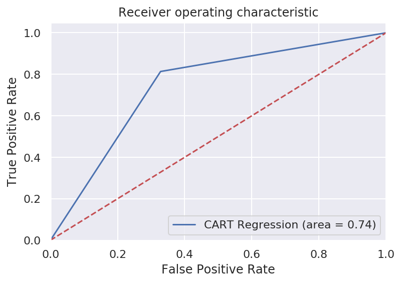

```python
# ROC curve

from sklearn.metrics import roc_auc_score
from sklearn.metrics import roc_curve

tree_performance = roc_auc_score(y_test, tree_preds)
fpr, tpr, thresholds = roc_curve(y_test, tree_preds)
plt.figure()
plt.plot(fpr, tpr, label='CART Regression (area = %0.2f)' % tree_performance)
plt.plot([0, 1], [0, 1],'r--')
plt.xlim([0.0, 1.0])
plt.ylim([0.0, 1.05])
plt.xlabel('False Positive Rate')
plt.ylabel('True Positive Rate')
plt.title('Receiver operating characteristic')
plt.legend(loc="lower right")
plt.savefig('CART_ROC.png')
plt.show()
```

#### Confusion Matrix

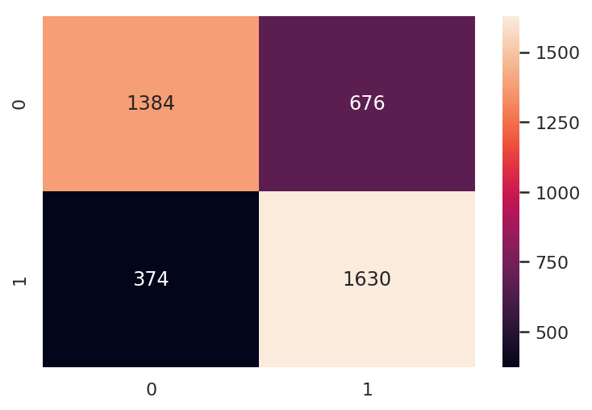

```python
tree_cm=metrics.confusion_matrix(y_test, tree_preds)
sns.heatmap(tree_cm, annot=True, fmt='d')
plt.savefig('confusionmat_CART.png')
```

## IV. Results

Note: please see jupyter notebook at /home/jovyan/Capstone-VL/code/casptone_model_selection_VLEE for more details/codes for model implementation and validation. For data, please refer to /home/jovyan/Capstone-VL/data folder. Finally, to review data pre-processing and missing value imputation, view /home/jovyan/Capstone-VL/code/capstone_data_preprocessing_EDA.

### Model Selection/Validation/Evaluation

CEO's regulatory focus was classified in two categories: promotion focus and prevention focus. CEO's regulatofy focus score was computed based on following steps:

1. Count term frequency(TF) of promotional words and preventional word used in the the shareholder's letter written by CEO. (I double counted the redundant word useage)
2. Calculate the % ratio of TF of CEO's promotion/prevention focus words over total promotion focus words/prevention focus words registered in the promotion/prevention regulatory focus dictionary.
3. was calculated based on the term frequency of each regulatory words used by the CEO in the shareholders' letter comparing to the total counts of each regulatory focus words in the dictionary.

**Logistic Regression Model** The train and test accuracies was around 64% (with a classification threshold of 0.5)—thus, overfitting does not appear to be a notable concern.

AUC-ROC (Area Under the Receiver Operating Characteristics) when trained on the train/test dataset was about 0.69.

Polynomial Regression model with degree of 1:

- RMSE of training set is 0.47.
- R2 score of training set is 0.12.
- RMSE of test set is 0.47.
- R2 score of test set is 0.12.

Polynomial Regression model with degree of 2:

- RMSE of training set is 0.45.
- R2 score of training set is 0.20.
- RMSE of test set is 0.45.
- R2 score of test set is 0.19.

Polynomial Regression model with degree of 3:

- RMSE of training set is 0.42.
- R2 score of training set is 0.30.
- RMSE of test set is 0.50.
- R2 score of test set is -0.01.

AUROC score is about 74% - thus, overfitting issue is not a severe concern with this model.

**Features:**

**Label:** Binary classification of historical M&A occurence of the company. 0, if no M&A occurred in the past. 1, if M&A occurred before. "M&A occurrence" simply means the company had acquired other companies before.

**Conclusion:** The prediction made by this model is trained/based on a specific set of CEO biographic and psychological attributes and Companies' general attributes. However, there are a number of other exogenous factors such as macro economic situation, event-driven shocks, and company's business objective that can affect company acquisition ocrruence.

Please consider this prediction only as the supplementary analysis on the future company M&A occurence predictions.

### Future Suggestion

For the future research, I may be able to add NLP analysis of the CEO shareholder's letters. Instead of relying on the relatively few regulatory focus words registered in two dictionaries, I would be able to do bag of words/word2vec analysis and visualize interactive NLP plots by sector and regulatory focus.

As this project alerady classified CEO's regulatory focus types, actually comparing binary group's most frequent words and using TF-IDF score would add new edges to this project.